# Milestone Report

Michael Berger

2 December 2018

## Abstract

In this project we will try to develop a word prediction system at typing. For this task we are provided by the JHU partner [SwiftKey](https://www.microsoft.com/en-us/swiftkey) with a large corpus of texts. We are supposed to use these texts to extract some frequent combinations of words we use in daily life to build our prediction algorithm from.

## Summaries

First, let’s see the scale of the problem. Since the files are very large and R is only able to work in-memory, I will use operating system’s wc operation to count lines, words and characters.

| file | size.MiB | lines | words | chars | wordsPerLine | charsPerLine |
| --- | --- | --- | --- | --- | --- | --- |
| en_US.blogs.txt | 200 | 899,288 | 37,334,117 | 210,160,014 | 42 | 234 |
| en_US.news.txt | 196 | 1,010,242 | 34,365,936 | 205,811,889 | 34 | 204 |
| en_US.twitter.txt | 159 | 2,360,148 | 30,373,559 | 167,105,338 | 13 | 71 |
| Total | 555 | 4,269,678 | 102,073,612 | 583,077,241 | 24 | 137 |

As one can see the numbers are truly enormous. I will try to use a 1% of the lines to perform some preliminary analyses. Also, looking ahead, running the analysis on all three files yelded pretty much similar results, so I will present it for only ‘en_US.blogs.txt’ file to avoid clogging up the report with duplicate information.

## Creating corpus

[output not shown]

```r
currentFile = 'en_US.blogs.txt'
if (is.na(get_lines(currentFile,1:2)[1])) # check that I can read from file
set.seed(42)
Lines <- sample_lines(currentFile, 1e4, files[currentFile,]$lines) #sample some lines from a file
Encoding(Lines) <- "latin1"  #remove non-ascii chars
Lines <- iconv(Lines, "latin1", "ASCII", sub="")
Lines <- gsub('_+', ' ', Lines, perl=T) #replace all underscores (including multiple _____) with whitespace
Corp <- corpus(char_tolower(Lines)) # everything to lowerCase and create corpus
paste(head(texts(Corp)))
```

```
[1] "model: sanja\n"
[2] "(3) in confidence, as a secret or private matter, not to be divulged or communicated to others; with belief in a persons sense of discretion: i told him in confidence.\n"
[3] "cheese thief gets jail sentence\n"
[4] "after the movie, it was about 12 at night and my cousin and her friends were planning on dropping me home first before they all went to hang out. however, i made the bad decision of calling my dad (who was probably really drunk at the time) if i could stay out a while longer to go eat. of cours…
[5] "if i write the stories, i could lose all the friends. if i don't write the stories, i could end up with a lame blog full of things my kids say. so i guess the question is, how much do i really like these people?\n"
[6] "can you see the bit of iridescence (and cat hair)? the fabric was lovely to work with  like a light weight linen. almost every bolt of fashion fabric at pa fabric outlets is marked 100% polyester. a few bolts reported rayon poly. this is obviously not 100% poly. its lightweight  really light  b…
```

## Tokenization

Creating word tokens, while removing unwanted tokens:  
- numbers  
- punctuation  
- symbols  
- separators  
- hyphens  
- URLs  
- twitter tags (but leaving the word after # in #hashtag)

```r
Toks<- tokens(Corp, what = "word", remove_numbers = T, remove_punct = T, remove_symbols = T,
  remove_separators = T, remove_twitter = T, remove_hyphens = T, remove_url = T)
```

And:  
- twitter rt tag  
- english stopwords  
- profane words

```r
l <- determine_nlines('profanity_words.txt') #read profanity vocabulary and convert to lower
profane <-char_tolower(get_lines('profanity_words.txt', 1:l))
profane <- profane[!is.na(profane)]
Toks<- tokens_remove(Toks, c(stopwords("english"), profane, "rt"))  # also remove ReTweet tag
```

# Stemming

Stemming is an operation of converting word to its root form. Example: caresses -> caress.  
I decided not to do stemming because:  
- it converts some words in a strange manner, like: ponies -> poni.  
- the model will output stemmed words as prediction which is undesirable.

## Document Frequency Matrix

A DFM is a matrix that stores number of appearances of each token. Essentially, it extracts all the unique words from a text together with total number of appearances of this word. At this step DFM is useful to spot unwanted words.

```r
Dfm1gr <- dfm(Toks, tolower = TRUE, stem = F)
```

### Check that non-ASCII characters actually got removed

If present, these chars should be immediately seen at the beginning or at the end of sorted tokens list.

```
## 00am; 00am10pm; 00p; 00pm; 00s; 010x; 0152p; 01am; 0.28mm; 02pm; 0.38mm; 0.3s; 043942089x; 0.45s; 0.4x; 0.500lb; 05am; 0.5c; 0.5mm; 0.6km; 0.6lbs; 0.72c; 07am; 0.7mm; 08am; 0.8km; 0.9m; 0a; 0care; 0f; 0rb; 0s; 0te; 0ut; 0z; 10,000ad; 10,000l; 1000miles; 1000p; 1000s; 1,000th; 1000w; 1009a; 100am;…
```

```
## zulkifeli; zulkifli; zulu; zulueta; zululand; zuma; zumas; zumba; zumbatomic; zumbo; zunis; zunker; zur; zuraida; zurich; zushi; zustande; zuzana; zuzkas; zuzu; zuzu's; zva; zvelebil; zvi; zviagintsev; zwar; zwei; zwelenzima; zwirner; zwischen; zwischenkieferbein; zwolle; zyada; zydeco; zygo; zyg…
```

And I see that there are none. Even though there are some pseudo-words here, like “100,00th”, these will be filtered out at a later step as having too low a frequency in the n-grams.

## Statistics

Since the data is very big, I have to find ways to make it smaller. First of all, it will become smaller due to structure of the model which compressees the data to just a database of unique tokens with their frequencies. Another way is to filter out terms that are of very low frequency.  
For this I need to determine how much data can be filtered out and still cover 90% of the words.

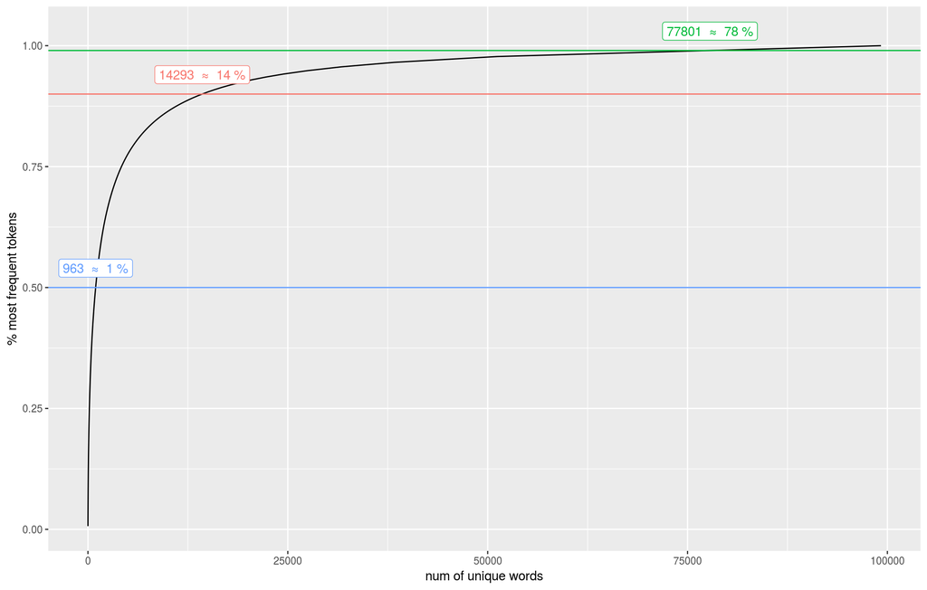

```r
freq1gr <- colSums(Dfm1gr)
freq1gr <- data.frame(words = names(freq1gr), freq = freq1gr , stringsAsFactors = F)
freq1gr  <- freq1gr[order(freq1gr$freq, decreasing = T),]
freq1gr$wc <- 1:nrow(freq1gr)
freq1gr$cs <- cumsum(freq1gr$freq)
freq1gr$perc <- freq1gr$cs/tail(freq1gr$cs,1)

closest <- function(w,x) #find closest value to x in a vector w. w must be sorted.
{
  dt = data.table(w, val = w)
  setattr(dt, "sorted", "w")
  return(dt[J(x), .I, roll = "nearest", by = .EACHI])
}

cl<-closest(freq1gr$perc,c(.5, .9, .99))
cl$p <- round((cl$I/nrow(freq1gr))*100)
cl$col <- brewer.pal(3, "Set1")
coverage <- ggplot(data = freq1gr ,aes(x = wc, y = perc)) + geom_line() +
              geom_hline(aes(yintercept =  w, col = col),data = cl, show.legend = F)  +
              geom_label(aes(x = I, y = w+.04, label=paste(I, " ≈ ", p ,"%"), col = col ), data = cl, show.legend = F) + xlab("num of unique words") + ylab("% most frequent tokens")
coverage
```

## N-grams

N-grams are a sequences of n words taken from a text and incorporated as a single token.  
So if a text was “The quick brown fox jumps over another quick brown fox” then 3-grams for it would be:

```
## The_quick_brown
##      quick_brown_fox
##            brown_fox_jumps
##                  fox_jumps_over
##                      jumps_over_another
##                            over_another_quick
##                                 another_quick_brown
##                                         quick_brown_fox
```

The next step is to create Document-feature matrix (DFM) out of these 3-grams. So for example in the case of 3-grams each token represents 3 consecutive words. So all the tokens in our example will have 1 appearance except for “quick_brown_fox”, which will have 2.

I will create 1, 2 and 3-grams for the document to get the general picture of the data. 1-gram is just dfm of single words which I’ve already created earlier.

```r
bigrams <- tokens_ngrams(Toks, 2)
trigrams <- tokens_ngrams(Toks, 3)

Dfm2gr <- dfm(bigrams, tolower = TRUE, stem = F)
Dfm3gr <- dfm(trigrams, tolower = TRUE, stem = F)
```

A plot of most frequent 1,2,3-grams shows us that even such simple algorithm is indeed able to locate frequent combinations of words we use in daily life.

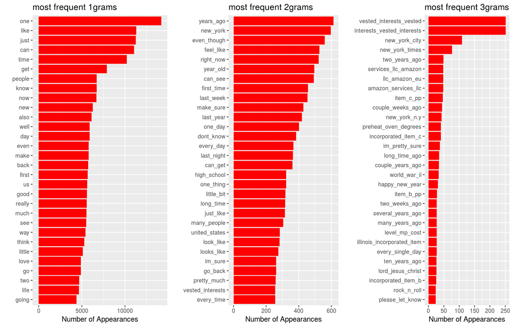

```r
tf <- topfeatures(Dfm2gr,30, scheme =  "count")
tf2 <- data.frame(words = names(tf), freq = tf , stringsAsFactors = F)

tf <- topfeatures(Dfm3gr,30, scheme =  "count")
tf3 <- data.frame(words = names(tf), freq = tf , stringsAsFactors = F)

plt1grm <- ggplot(head(freq1gr,30), aes(x=reorder(words, freq), y=freq)) +
        geom_bar(stat="Identity", fill='red') + xlab("") +
        coord_flip() + ylab("Number of Appearances") + ggtitle("most frequent 1grams")

plt2grm <- ggplot(head(tf2,30), aes(x=reorder(words, freq), y=freq)) +
        geom_bar(stat="Identity", fill='red') + xlab("") +
        coord_flip() + ylab("Number of Appearances") + ggtitle("most frequent 2grams")

plt3grm <- ggplot(head(tf3,30), aes(x=reorder(words, freq), y=freq)) +
        geom_bar(stat="Identity", fill='red') + xlab("") +
        coord_flip() + ylab("Number of Appearances") + ggtitle("most frequent 3grams")

grid.arrange(plt1grm, plt2grm, plt3grm, ncol=3)
```

## Questions to consider

Here are some preprocessing steps which could further improve the model, but I decided to skip them because they will require a lot of time to develop.  
-Do a segmentation of twitter hashtags into separate words (like #hashtag -> hash tag) . -Substitute or remove tokens which start with a number (like “10,000th -> th” ) -Maybe better not to remove stopwords since they are an essential part of speech and wothout them the sentences will be syntactically incorrect.

## Next steps

So judging from this overview, a straightforward solution to the project’s goal seems simple:  
-Pre-calculate a frequencies database for all 1,2,3,4, maybe 5-grams.  
-For every new word in a sequence that a user types, find in the database all n-grams that begin similarly  
-Calculate a degree of fit for every found n-gram according to some formula  
-Select n-gram with best fit.

## Implementation

Since the given data is truly enormous and can’t fit into memory, I will have to process it in chunks, saving only ngrams and frequencies in an SQL database.

## Conclusion

In this report I have performed a brief overview of the data that is avilable and arrived at an idea as to how it may be useful for creating a prediction model.